# Linear Regression

In this module, you’ll learn to compute linear regression models in R.

▶️ Watch Videos: 30 minutes

- 🔗 Link to **all** Slides from Videos: [here](https://app.box.com/s/zcnbbt2xepty8ztg56ikdgdxz8oiyvws)

📖 Readings: 45-60 minutes

💻 Activities: 30 minutes

✅ Preview Activity: 1

## 1 Review of Simple (Basic) Linear Regression

📖 [Recommended Reading – *Modern Dive* : Basic Regression](https://moderndive.com/5-regression.html)

▶️ [Recommended Video – Simple Linear Regression (17 minutes)](https://www.youtube.com/watch?v=1IMpg1ukMpY)

## 2 Conditions of Linear Regression

📖 [Recommended Readign – *Modern Dive*: Conditions for inference for regression](https://moderndive.com/10-inference-for-regression.html#regression-conditions)

🎮 [Recommended Video – Regression Assumptions (14 minutes)](https://www.youtube.com/watch?v=LD3OSSVxKMU)

## 3 Visualizing Linear Regression

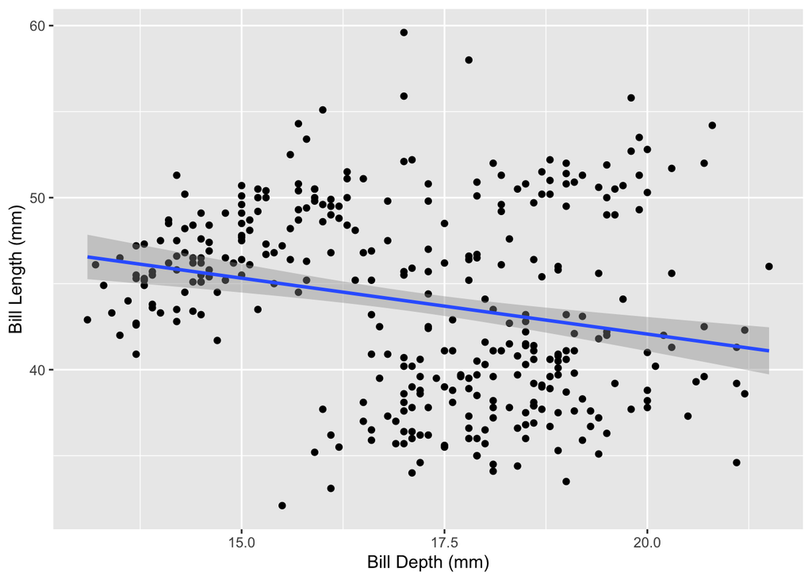

```r
library(palmerpenguins)

penguins %>%
  ggplot(aes(x = bill_depth_mm, y = bill_length_mm)) +
  geom_point() +
  stat_smooth(method = "lm") +
  labs(x = "Bill Depth (mm)",
       y = "Bill Length (mm)")
```

## 4 Fitting Linear Regression Models in R – Supervised Learning

Fitting regression models in R is very simple, you can use the `lm()` function, with the formula: `reponse ~ explanatory`. If you look at the help file for `lm()`, you’ll notice that the `data`set is specified in the **second** argument, which makes it so that we need to specify *where* the piped data is being input into the function.

We can do this “specifying” using the `_` symbol, as seen in the code below:

```r
my_model <- penguins |>
  lm(bill_length_mm ~ bill_depth_mm, data = _)
```

## 5 Accessing Model Estimates

### Raw Coefficients

This is what is output when you just call the name of the linear model object you created (`my_model`). Notice, the output doesn’t give you much information and it looks kind of bad (not something you’d want to put in a report).

```r
my_model
```

```
Call:
lm(formula = bill_length_mm ~ bill_depth_mm, data = penguins)

Coefficients:
  (Intercept)  bill_depth_mm
      55.0674        -0.6498
```

### Model Summary

This is what is output when you use the `summary()` function on a linear model object. Notice, the output gives you a lot of information, some of which is really not that useful. And, the output is quite messy!

```r
summary(my_model)
```

```
Call:
lm(formula = bill_length_mm ~ bill_depth_mm, data = penguins)

Residuals:
     Min       1Q   Median       3Q      Max
-12.8949  -3.9042  -0.3772   3.6800  15.5798

Coefficients:
              Estimate Std. Error t value Pr(>|t|)
(Intercept)    55.0674     2.5160  21.887  < 2e-16 ***
bill_depth_mm  -0.6498     0.1457  -4.459 1.12e-05 ***
---
Signif. codes:  0 '***' 0.001 '**' 0.01 '*' 0.05 '.' 0.1 ' ' 1

Residual standard error: 5.314 on 340 degrees of freedom
  (2 observations deleted due to missingness)
Multiple R-squared:  0.05525,   Adjusted R-squared:  0.05247
F-statistic: 19.88 on 1 and 340 DF,  p-value: 1.12e-05
```

### Tidy Model Summary

The `tidy()` function from the broom package takes a linear model object and puts the “important” information into a tidy tibble output.

```r
broom::tidy(my_model)
```

```
# A tibble: 2 × 5
  term          estimate std.error statistic  p.value
  <chr>            <dbl>     <dbl>     <dbl>    <dbl>
1 (Intercept)     55.1       2.52      21.9  6.91e-67
2 bill_depth_mm   -0.650     0.146     -4.46 1.12e- 5
```

Ah! Just right!

If you are sad that you no longer have the statistics about the model fit (e.g., R-squared, adjusted R-squared, $\sigma$), you can use the `glance()` function from the broom package to grab those!

```r
broom::glance(my_model)
```

```
# A tibble: 1 × 12
  r.squ…¹ adj.r…² sigma stati…³ p.value    df logLik   AIC   BIC devia…⁴ df.re…⁵
    <dbl>   <dbl> <dbl>   <dbl>   <dbl> <dbl>  <dbl> <dbl> <dbl>   <dbl>   <int>
1  0.0552  0.0525  5.31    19.9 1.12e-5     1 -1056. 2117. 2129.   9603.     340
# … with 1 more variable: nobs <int>, and abbreviated variable names
#   ¹r.squared, ²adj.r.squared, ³statistic, ⁴deviance, ⁵df.residual
```

## 6 Preview Activity: Linear Regression

**Question 1:** If you switch the order of `bill_length_mm` and `bill_depth_mm` in the `lm()` formula nothing happens.

- True
- False

**Question 2:** What *object type* was returned by `summary()`?

- list
- vector
- dataframe

**Question 3:** What *object type* was returned by `tidy()`?

- list
- vector
- dataframe

**Question 4:** Penguin Mopsy has a bill that is 5mm deeper than Penguin Gidget. What will be the difference between their bill lengths?

- Mopsy’s length is 3.25mm shorter than Gidget
- Mopsy’s length is 3.25mm longer than Gidget

**Question 5:**

Run the following code, and explore the results:

```r
my_model_2 <- penguins |>
  lm(bill_length_mm ~ bill_depth_mm*species, data = _)
```

Make a plot illustrating `my_model_2`. Upload a picture of your plot!

**Tip**

Hint: Think about what needs to change in the aesthetic of the plot featured previously!

**Question 6:** Which model of the two models explains the most variance in `bill_length_mm`?

- `my_model`
- `my_model_2`

**Question 7:** Do the three species of penguin have the same bill shape (i.e., the relationship between length and depth)?